# Klasyfikacja użytkowników i botów

#### Adrian Siwek, 223296 Mateusz Pszczółkowski, 223315 Kamil Pracki, 223510

## 1. Wprowadzenie

W ostatnich latach dynamiczny rozwój sztucznej inteligencji oraz narzędzi do automatycznego generowania treści znacząco wpłynął na sposób funkcjonowania mediów społecznościowych. Coraz częściej obserwuje się obecność kont, które nie są zarządzane przez realnych użytkowników, lecz przez algorytmy – tzw. boty. Takie konta mogą służyć m.in. do rozpowszechniania dezinformacji, sztucznego zwiększania zasięgów czy manipulowania opinią publiczną. W związku z rosnącym znaczeniem tego zjawiska, umiejętność odróżnienia kont rzeczywistych od botów staje się coraz ważniejsza – zarówno z perspektywy indywidualnych użytkowników, jak i badaczy analizujących dane społecznościowe.

## Przedmiot badania

### Cel i zakres badania

Celem badania jest przeprowadzenie klasyfikacji kont użytkowników platformy vk.com w celu odróżnienia kont autentycznych od botów. W tym celu zastosowano różne metody uczenia maszynowego: las losowy, gradient boosting oraz regresję logistyczną. Zakres badania obejmuje 5874 konta użytkowników portalu vk.com, których dane zostały pobrane z publicznie dostępnych profili.

## 2. Eksploracja i analiza danych

### Opis zbioru danych

W zbiorze danych znajduje się 60 cech, które opisują standardowe charakterystyki kont pojawiających się na mediach społecznościowych jak ilość umieszczoncyh postów, ilość polubień, czy informacje o profilu użytkownika.

### Zmienne

W celu uproszczenia analizy i zwiększenia przejrzystości, wszystkie zmienne w zbiorze danych zostały nazwane zgodnie z logicznymi schematami nazewnictwa. Dzięki temu użytkownik może z łatwością zrozumieć, czego dotyczy dana zmienna, nawet bez znajomości szczegółów jej zawartości.

#### Zmienne zaczynające się od has_ informują, czy dana informacja została uzupełniona przez użytkownika.

1. has_domain
2. has_birth_date
3. has_photo
4. has_website
5. has_short_name
6. has_first_name
7. has_last_name
8. has_nickname
9. has_maiden_name
10. has_mobile
11. has_interests
12. has_books
13. has_tv
14. has_quotes
15. has_about
16. has_games
17. has_movies
18. has_activities
19. has_music
20. has_career
21. has_military_service
22. has_hometown
23. has_universities
24. has_schools
25. has_relatives
26. has_status
27. has_occupation
28. has_personal_data

#### Zmienne zaczynające się od is_, określają status profilu użytkownika

1. is_profile_closed
2. is_blacklisted
3. is_verified
4. is_confirmed

#### Zmienne zaczynające się od can_, wskazują na możliwości interakcji z innymi użytkownikami

1. can_post_on_wall
2. can_send_message
3. can_add_as_friend
4. can_invite_to_group

#### Zmienne ilościowe dotyczące aktywności profilu

1. posts_count
2. avg_likes
3. links_ratio
4. hashtags_ratio
5. avg_keywords
6. avg_text_length
7. attachments_ratio
8. avg_comments
9. reposts_ratio
10. ads_ratio
11. avg_views
12. posting_frequency_days
13. phone_numbers_ratio
14. avg_text_uniqueness

#### Pozostałe zmienne typu boolean

1. access_to_closed_profile
2. all_posts_visible
3. audio_available
4. occupation_type_university
5. occupation_type_work

#### Pozostałe zmienne ogólne

1. gender
2. marital_status
3. subscribers_count
4. city

#### Target

Zmienna target pełni rolę etykiety klas w zadaniu klasyfikacyjnym. Przyjmuje dwie wartości:  
0 – oznacza konto prawdziwego użytkownika (autentyczne),  
1 – oznacza konto bota (automatyczne).

#### Wyświetlenie zawartości pliku z danymi

```python
import pandas as pd
import seaborn as sns
import matplotlib.pyplot as plt
import numpy as np
import scipy.stats as ss
import warnings
warnings.filterwarnings('ignore')

df = pd.read_csv("bots_vs_users.csv")
df.head()
```

|  | has_domain | has_birth_date | has_photo | can_post_on_wall | can_send_message | has_website | gender | has_short_name | has_first_name | has_last_name | ... | ads_ratio | avg_views | posting_frequency_days | phone_numbers_ratio | avg_text_uniqueness | city | has_occupation | occupation_type_university | occupation_type_work | has_personal_data |
| --- | --- | --- | --- | --- | --- | --- | --- | --- | --- | --- | --- | --- | --- | --- | --- | --- | --- | --- | --- | --- | --- |
| 0 | 1.0 | 1.0 | 0.0 | 0.0 | 0.0 | 0.0 | 1.0 | 1.0 | 1.0 | 1.0 | ... | NaN | NaN | NaN | NaN | NaN | Unknown | Unknown | Unknown | Unknown | Unknown |
| 1 | 1.0 | 1.0 | 0.0 | 0.0 | 0.0 | 0.0 | 1.0 | 1.0 | 1.0 | 1.0 | ... | NaN | NaN | NaN | NaN | NaN | Unknown | Unknown | Unknown | Unknown | Unknown |
| 2 | 1.0 | 1.0 | 0.0 | 0.0 | 0.0 | 0.0 | 1.0 | 1.0 | 1.0 | 1.0 | ... | NaN | NaN | NaN | NaN | NaN | Unknown | Unknown | Unknown | Unknown | Unknown |
| 3 | 1.0 | 1.0 | 0.0 | 0.0 | 0.0 | 0.0 | 1.0 | 1.0 | 1.0 | 1.0 | ... | NaN | NaN | NaN | NaN | NaN | Unknown | Unknown | Unknown | Unknown | Unknown |
| 4 | 1.0 | 1.0 | 0.0 | 0.0 | 0.0 | 0.0 | 1.0 | 1.0 | 1.0 | 1.0 | ... | NaN | NaN | NaN | NaN | NaN | Unknown | Unknown | Unknown | Unknown | Unknown |

5 rows × 60 columns

#### Wstępne informacje o zbiorze danych

```python
df.info()
```

```
<class 'pandas.core.frame.DataFrame'>
RangeIndex: 5874 entries, 0 to 5873
Data columns (total 60 columns):
 #   Column                      Non-Null Count  Dtype
---  ------                      --------------  -----
 0   has_domain                  5874 non-null   object
 1   has_birth_date              5874 non-null   object
 2   has_photo                   5874 non-null   object
 3   can_post_on_wall            5874 non-null   object
 4   can_send_message            5874 non-null   object
 5   has_website                 5874 non-null   object
 6   gender                      5874 non-null   object
 7   has_short_name              5874 non-null   object
 8   has_first_name              5874 non-null   object
 9   has_last_name               5874 non-null   object
```

[output cut: 52 more lines]

#### Analiza brakujących wartości (Null oraz 'Unknown') w zbiorze

```python
pd.DataFrame(
    {
        "Null": df.isna().sum(),
        "Unknown": (df == "Unknown").sum(),
        "Procent pustych/nieznanych danych": (df.isna().sum() + (df == "Unknown").sum())
        / df.shape[0]
        * 100,
    }
)
```

|  | Null | Unknown | Procent pustych/nieznanych danych |
| --- | --- | --- | --- |
| has_domain | 0 | 24 | 0.408580 |
| has_birth_date | 0 | 856 | 14.572693 |
| has_photo | 0 | 24 | 0.408580 |
| can_post_on_wall | 0 | 24 | 0.408580 |
| can_send_message | 0 | 24 | 0.408580 |
| has_website | 0 | 742 | 12.631937 |
| gender | 0 | 24 | 0.408580 |
| has_short_name | 0 | 24 | 0.408580 |
| has_first_name | 0 | 24 | 0.408580 |
| has_last_name | 0 | 24 | 0.408580 |
| access_to_closed_profile | 0 | 24 | 0.408580 |
| is_profile_closed | 0 | 24 | 0.408580 |
| target | 0 | 0 | 0.000000 |
| has_nickname | 0 | 2556 | 43.513790 |
| has_maiden_name | 0 | 3416 | 58.154580 |
| has_mobile | 0 | 2556 | 43.513790 |
| all_posts_visible | 0 | 2556 | 43.513790 |
| audio_available | 0 | 2556 | 43.513790 |
| has_interests | 0 | 4601 | 78.328226 |
| has_books | 0 | 4601 | 78.328226 |
| has_tv | 0 | 4601 | 78.328226 |
| has_quotes | 0 | 4601 | 78.328226 |
| has_about | 0 | 4601 | 78.328226 |
| has_games | 0 | 4601 | 78.328226 |
| has_movies | 0 | 4601 | 78.328226 |
| has_activities | 0 | 4601 | 78.328226 |
| has_music | 0 | 4601 | 78.328226 |
| can_add_as_friend | 0 | 2556 | 43.513790 |
| can_invite_to_group | 0 | 2556 | 43.513790 |
| subscribers_count | 0 | 3274 | 55.737147 |
| is_blacklisted | 0 | 2556 | 43.513790 |
| has_career | 0 | 4601 | 78.328226 |
| has_military_service | 0 | 4601 | 78.328226 |
| has_hometown | 0 | 4601 | 78.328226 |
| marital_status | 0 | 4601 | 78.328226 |
| has_universities | 0 | 4601 | 78.328226 |
| has_schools | 0 | 4601 | 78.328226 |
| has_relatives | 0 | 4601 | 78.328226 |
| is_verified | 0 | 2556 | 43.513790 |
| is_confirmed | 0 | 2556 | 43.513790 |
| has_status | 0 | 2964 | 50.459653 |
| posts_count | 4483 | 0 | 76.319374 |
| avg_likes | 4483 | 0 | 76.319374 |
| links_ratio | 4483 | 0 | 76.319374 |
| hashtags_ratio | 4483 | 0 | 76.319374 |
| avg_keywords | 4483 | 0 | 76.319374 |
| avg_text_length | 4483 | 0 | 76.319374 |
| attachments_ratio | 4483 | 0 | 76.319374 |
| avg_comments | 4483 | 0 | 76.319374 |
| reposts_ratio | 4483 | 0 | 76.319374 |
| ads_ratio | 4483 | 0 | 76.319374 |
| avg_views | 4483 | 0 | 76.319374 |
| posting_frequency_days | 4483 | 0 | 76.319374 |
| phone_numbers_ratio | 4483 | 0 | 76.319374 |
| avg_text_uniqueness | 4483 | 0 | 76.319374 |
| city | 0 | 2780 | 47.327205 |
| has_occupation | 0 | 3497 | 59.533538 |
| occupation_type_university | 0 | 3497 | 59.533538 |
| occupation_type_work | 0 | 3497 | 59.533538 |
| has_personal_data | 0 | 5006 | 85.223017 |

### Wartości odstające

W tym przypadku, nie wymagały one osobnej obserwacji ani obsługi, ponieważ nietypowe zachowania często są sygnałami obecności botów. Model do wykrywania botów właśnie na tym się opiera – wykorzystuje te "odstające" cechy, aby efektywniej rozpoznawać nieautentyczne konta. Traktowanie ich jako błędów i ich usuwanie obniżyłoby zdolność modelu do nauki i identyfikacji botów.

### Czyszczenie, kodowanie danych oraz ich braki

Część analizowanych przez nas danych nie zawierała wszystkich informacji. Wynika to ze sposobu pozyskania badanych danych – to jest zbieranie **danych tylko widocznych** dla każdego użytkownika. Jednak nazwanie tego brakiem danych byłoby błędne, ponieważ ukrycie lub niewypełnienie jakiegoś pola w profilu też jest informacją, którą wykorzystujemy w badaniu.

Aby móc wykorzystać te informacje, użyliśmy **kodowania** – czyli zmiana zmiennych nienumerycznych na numeryczne. W naszym przypadku `null` oraz `undefined` na `-1`.

```python
from sklearn.pipeline import Pipeline
from sklearn.preprocessing import FunctionTransformer

def drop_all_nan_columns(X):
    if isinstance(X, pd.DataFrame):
        return X.dropna(axis=1, how="all")
    return X

def replace_unknown_and_nan(X):
    if isinstance(X, pd.DataFrame):
        X = X.replace("Unknown", -1)
        X = X.fillna(-1)
        return X
    return X

cleaning_pipeline = Pipeline([
    ("drop_all_nan_cols", FunctionTransformer(drop_all_nan_columns, validate=False)),
    ("replace_unknown_nan", FunctionTransformer(replace_unknown_and_nan, validate=False)),
])

df = cleaning_pipeline.fit_transform(df)
```

#### Kodowanie

Większość algorytmów uczenia maszynowego nie potrafi operować na danych tekstowych. Wymagają one, aby zarówno cechy (zmienne objaśniające), jak i etykiety (zmienna objaśniana) były w formacie numerycznym.

- **Problem:** Etykiety klas, takie jak `bot` czy `human`, są niezrozumiałe dla algorytmów matematycznych.
- **Korzyści:** Jest to niezbędny krok w przetwarzaniu wstępnym danych, który umożliwia zastosowanie algorytmów klasyfikacyjnych.

```python
def transform_city_column(X):
    if isinstance(X, pd.DataFrame) and "city" in X.columns:
        X["city"] = X["city"].apply(lambda x: 1 if x != -1 else -1)
        X.rename(columns={"city": "has_city"}, inplace=True)

    return X

pipeline_v2 = Pipeline([
    ("cleaning", cleaning_pipeline),
    ("transform_city", FunctionTransformer(transform_city_column, validate=False)),
])

df = pipeline_v2.fit_transform(df)
```

#### Zamiana typu zmiennych z `object` na numeryczne

```python
for col in df.columns:
    if df[col].dtype == "object":
        df[col] = pd.to_numeric(df[col], errors="coerce")
```

#### Informacje o zbiorze po czyszczeniu

```python
df.info()
```

```
<class 'pandas.core.frame.DataFrame'>
RangeIndex: 5874 entries, 0 to 5873
Data columns (total 60 columns):
 #   Column                      Non-Null Count  Dtype
---  ------                      --------------  -----
 0   has_domain                  5874 non-null   float64
 1   has_birth_date              5874 non-null   float64
 2   has_photo                   5874 non-null   float64
 3   can_post_on_wall            5874 non-null   float64
 4   can_send_message            5874 non-null   float64
 5   has_website                 5874 non-null   float64
 6   gender                      5874 non-null   float64
 7   has_short_name              5874 non-null   float64
 8   has_first_name              5874 non-null   float64
 9   has_last_name               5874 non-null   float64
```

[output cut: 52 more lines]

### Analiza statystyczna zmiennych

### Statystyki opisowe

- Średnia: Wartość, która informuje nas o przeciętnym poziomie danej zmiennej w zbiorze danych. Przykładowo średnią cenę za metr kwadratowy w Warszawie, która daje punkt odniesienie przy wyborze mieszkania
- Mediana: Wartość środkowa w uporządkowanym zbiorze danych, która dzieli dane na dwie równe części. Jest lepszym wyborem niż średnia, gdy dane mogą być zniekształcone przez wartości skrajne. Przykładowo średnia ceny może być zniekształcona przez bardzo duże mieszkania
- Minimum: Najniższa wartość w zbiorze danych
- Maksimum: Najwyższa wartość w zbiorze danych
- Odchylenie standardowe: Miara rozproszenia danych wokół średniej. Może ona pokazać czy na przykład ceny za metr kwadratowy w mieście są zróżnicowane czy zbliżone do siebie.
- Skośność: Mierzy asymetrię rozkładu danych, wskazując, czy dane są bardziej skupione po jednej stronie średniej. Przykładowo pokazuje czy powierzchnia większości mieszkań jest większa czy mniejsza od średniej.

#### Statystyki dla danych numerycznych

```python
df_num = df[[col for col in df.columns if df[col].nunique() > 10]]

pd.DataFrame(
    {
        "Count": df_num.count(),
        "Mean": df_num.mean(),
        "Median": df_num.median(),
        "Min": df_num.min(),
        "Max": df_num.max(),
        "Std": df_num.std(),
        "Skew": df_num.skew(),
    }
)
```

|  | Count | Mean | Median | Min | Max | Std | Skew |
| --- | --- | --- | --- | --- | --- | --- | --- |
| subscribers_count | 5874 | 765.606401 | -1.0 | -1.0 | 103729.00 | 2545.336504 | 15.361513 |
| posts_count | 5874 | 3.648281 | -1.0 | -1.0 | 20.00 | 8.595666 | 1.346417 |
| avg_likes | 5874 | 3.866958 | -1.0 | -1.0 | 894.90 | 22.202575 | 20.413907 |
| links_ratio | 5874 | -0.726142 | -1.0 | -1.0 | 1.00 | 0.501474 | 1.397568 |
| hashtags_ratio | 5874 | -0.729113 | -1.0 | -1.0 | 1.00 | 0.494790 | 1.378204 |
| avg_keywords | 5874 | 1.067475 | -1.0 | -1.0 | 61.60 | 6.624632 | 4.992843 |
| avg_text_length | 5874 | 128.237501 | -1.0 | -1.0 | 5841.25 | 431.056682 | 5.165787 |
| attachments_ratio | 5874 | -0.551028 | -1.0 | -1.0 | 1.00 | 0.810313 | 1.269264 |
| avg_comments | 5874 | -0.618550 | -1.0 | -1.0 | 64.05 | 1.379595 | 22.496507 |
| reposts_ratio | 5874 | -0.660506 | -1.0 | -1.0 | 1.00 | 0.639513 | 1.561622 |
| avg_views | 5874 | 146.964792 | -1.0 | -1.0 | 41415.70 | 830.598234 | 27.476598 |
| posting_frequency_days | 5874 | 14.944181 | -1.0 | -1.0 | 2866.59 | 80.643751 | 19.265089 |
| avg_text_uniqueness | 5874 | -0.605005 | -1.0 | -1.0 | 1.00 | 0.717927 | 1.313639 |

#### Podstawowe wnioski i zależności wynikające z analizy dla zmiennych numerycznych

1. Bardzo silna skośność (Skewness) - Wiele cech ma ekstremalnie wysoką skośność dodatnią:
   - avg_views
   - avg_comments
   - avg_likes
   - subscribers_count
   - posting_frequency_days

   Większość kont ma bardzo niskie wartości, a nieliczne konta mają ekstremalne wyniki. To typowe dla prawdziwych użytkowników (naturalna dystrybucja popularności), ale boty często „odstają” – albo mają prawie zerowe interakcje, albo nienaturalnie wysoką aktywność.
2. Mediana = -1 dla wszystkich zmiennych

   `-1` to kod brakującej wartości co jest silnym sygnałem klasy bota, które:
   - nie mają komentarzy
   - nie mają repostów
   - nie używają hashtagów
   - nie generują views
3. Cechy proporcji (ratio) bliskie 0

Zmienne:

- links_ratio
- hashtags_ratio
- attachments_ratio
- reposts_ratio
- avg_text_uniqueness

Mają względnie duże odchylenie standardowe (0.5 do 0.8) patrząc na to, że są zmienne te mają maksymalne wartości równe 1.  
Wynika to z tego, że boty często wrzucają same linki, albo zawsze ten sam schemat posta lub mają niską unikalność tekstu.  
Natomiast treść postów użytkowników jest bardziej "chaotyczna" oraz mają bardziej zróżnicowane proporcje.

#### Statystyki dla danych binarnych/kategorycznych

```python
df_bin = df[[col for col in df.columns if df[col].nunique() < 10]]

pd.DataFrame(
    {
        "Count": df_bin.count(),
        "Mean": df_bin.mean(),
        "Median": df_bin.median(),
        "0 precent": [
            round(len(df[df_bin[col] == 0]) / df.shape[0] * 100, 2)
            for col in df_bin.columns
        ],
        "1 percent": [
            round(len(df[df_bin[col] == 1]) / df.shape[0] * 100, 2)
            for col in df_bin.columns
        ],
        "-1 percent": [
            round(len(df[df_bin[col] == -1]) / df.shape[0] * 100, 2)
            for col in df_bin.columns
        ],
    }
)
```

|  | Count | Mean | Median | 0 precent | 1 percent | -1 percent |
| --- | --- | --- | --- | --- | --- | --- |
| has_domain | 5874 | 0.991828 | 1.0 | 0.00 | 99.59 | 0.41 |
| has_birth_date | 5874 | 0.708546 | 1.0 | 0.00 | 85.43 | 14.57 |
| has_photo | 5874 | 0.546136 | 1.0 | 44.57 | 55.02 | 0.41 |
| can_post_on_wall | 5874 | 0.034559 | 0.0 | 95.73 | 3.86 | 0.41 |
| can_send_message | 5874 | 0.438713 | 0.0 | 55.31 | 44.28 | 0.41 |
| has_website | 5874 | -0.007831 | 0.0 | 75.52 | 11.85 | 12.63 |
| gender | 5874 | 1.208716 | 1.0 | 0.54 | 76.81 | 0.41 |
| has_short_name | 5874 | 0.991828 | 1.0 | 0.00 | 99.59 | 0.41 |
| has_first_name | 5874 | 0.991828 | 1.0 | 0.00 | 99.59 | 0.41 |
| has_last_name | 5874 | 0.990807 | 1.0 | 0.10 | 99.49 | 0.41 |
| access_to_closed_profile | 5874 | 0.862615 | 1.0 | 12.92 | 86.67 | 0.41 |
| is_profile_closed | 5874 | 0.125128 | 0.0 | 86.67 | 12.92 | 0.41 |
| target | 5874 | 0.500000 | 0.5 | 50.00 | 50.00 | 0.00 |
| has_nickname | 5874 | -0.404154 | 0.0 | 53.39 | 3.10 | 43.51 |
| has_maiden_name | 5874 | -0.497446 | -1.0 | 33.44 | 8.41 | 58.15 |
| has_mobile | 5874 | 0.102145 | 1.0 | 2.76 | 53.73 | 43.51 |
| all_posts_visible | 5874 | -0.244467 | 0.0 | 37.42 | 19.07 | 43.51 |
| audio_available | 5874 | -0.200034 | 0.0 | 32.98 | 23.51 | 43.51 |
| has_interests | 5874 | -0.743105 | -1.0 | 17.65 | 4.02 | 78.33 |
| has_books | 5874 | -0.756725 | -1.0 | 19.02 | 2.66 | 78.33 |
| has_tv | 5874 | -0.767109 | -1.0 | 20.05 | 1.62 | 78.33 |
| has_quotes | 5874 | -0.744467 | -1.0 | 17.79 | 3.88 | 78.33 |
| has_about | 5874 | -0.740041 | -1.0 | 17.35 | 4.32 | 78.33 |
| has_games | 5874 | -0.763704 | -1.0 | 19.71 | 1.96 | 78.33 |
| has_movies | 5874 | -0.755192 | -1.0 | 18.86 | 2.81 | 78.33 |
| has_activities | 5874 | -0.726932 | -1.0 | 16.04 | 5.64 | 78.33 |
| has_music | 5874 | -0.757746 | -1.0 | 19.12 | 2.55 | 78.33 |
| can_add_as_friend | 5874 | 0.057712 | 0.0 | 7.20 | 49.28 | 43.51 |
| can_invite_to_group | 5874 | -0.367041 | 0.0 | 49.68 | 6.81 | 43.51 |
| is_blacklisted | 5874 | -0.435138 | 0.0 | 56.49 | 0.00 | 43.51 |
| has_career | 5874 | -0.721144 | -1.0 | 15.46 | 6.21 | 78.33 |
| has_military_service | 5874 | -0.778515 | -1.0 | 21.20 | 0.48 | 78.33 |
| has_hometown | 5874 | -0.669220 | -1.0 | 10.27 | 11.41 | 78.33 |
| marital_status | 5874 | -0.516003 | -1.0 | 14.78 | 0.80 | 78.33 |
| has_universities | 5874 | -0.692373 | -1.0 | 12.58 | 9.09 | 78.33 |
| has_schools | 5874 | -0.700034 | -1.0 | 13.35 | 8.32 | 78.33 |
| has_relatives | 5874 | -0.730167 | -1.0 | 16.36 | 5.31 | 78.33 |
| is_verified | 5874 | -0.416241 | 0.0 | 54.60 | 1.89 | 43.51 |
| is_confirmed | 5874 | -0.434968 | 0.0 | 56.47 | 0.02 | 43.51 |
| has_status | 5874 | -0.285666 | -1.0 | 27.65 | 21.89 | 50.46 |
| ads_ratio | 5874 | -0.762562 | -1.0 | 23.12 | 0.00 | 76.32 |
| phone_numbers_ratio | 5874 | -0.763059 | -1.0 | 23.53 | 0.00 | 76.32 |
| has_city | 5874 | 0.053456 | 1.0 | 0.00 | 52.67 | 47.33 |
| has_occupation | 5874 | -0.190671 | -1.0 | 0.00 | 40.47 | 59.53 |
| occupation_type_university | 5874 | -0.345250 | -1.0 | 15.46 | 25.01 | 59.53 |
| occupation_type_work | 5874 | -0.442629 | -1.0 | 25.20 | 15.27 | 59.53 |
| has_personal_data | 5874 | -0.704460 | -1.0 | 0.00 | 14.78 | 85.22 |

#### Podstawowe wnioski i zależności wynikające z analizy zmiennych kategorycznych

Konta użytkowników charakteryzują się kompletnością. Prawdziwi użytkownicy częściej: uzupełniają dane osobowe, zamykają profile, mają zdjęcia i imiona/nazwiska. Z kolei boty nie uzupełniają informacji o sobie, ich konta są puste i nie posiadają interakcji z innymi użytkownikami.

## 3. Wizualizacja danych

```python
bins = {"cat":[], "num":[]}
for col in df.columns:
    if col == "target":
        continue
    elif df[col].nunique() < 10:
        bins["cat"].append(col)
    else:
        bins["num"].append(col)

print("Ilość cech binarnych/kategorycznych:", len(bins["cat"]), "\nIlość cech numerycznych:", len(bins["num"]))
```

```
Ilość cech binarnych/kategorycznych: 46
Ilość cech numerycznych: 13
```

Z powodu, że w zbiorze danych mamy dużą ilość cech binarnych/kategorycznych to zwizualizujemy te, które wydają się najbardziej istotne dla problemu rozpoznawania botów/użytkowników.

#### Wizualizacja danych kategorycznych w zależności od target

[figure not shown]

```python
fig, axes = plt.subplots(4, 3, figsize=(12, 8))

cat_to_plot = ["has_photo", "can_send_message", "is_profile_closed", "has_nickname", "has_mobile", "has_maiden_name", "has_schools",
               "audio_available", "can_add_as_friend", "has_status", "has_city", "has_occupation"]

axes = axes.flatten()

for idx, col in enumerate(cat_to_plot):
    sns.countplot(x=col, hue="target", data=df, ax=axes[idx])
    axes[idx].set_title(f"Rozkład: {col}")
    #axes[idx].tick_params(axis="x", rotation=45)
    axes[idx].legend(title='Klasa', labels=['Użytkownicy', 'Boty'])
    axes[idx].set_xlabel(col)
    axes[idx].set_ylabel("Wystąpienia")
    axes[idx].set_xticklabels(['Nieznane', "Nie", "Tak"])

plt.tight_layout()
plt.show()
```

#### Wizualizacja najciekawszych zależności między targetem a zmiennymi numerycznymi

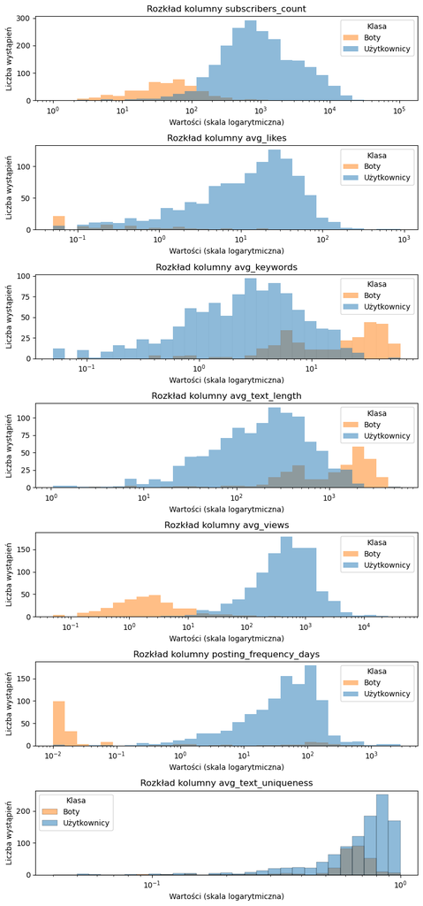

```python
fig, axes = plt.subplots(7, 1, figsize=(8, 17))
features = ["subscribers_count", "avg_likes", "avg_keywords","avg_text_length",
            "avg_views", "posting_frequency_days", "avg_text_uniqueness"]

axes = axes.flatten()

for i, col in enumerate(features):
    data = df[df[col] > 0]
    bins_log = np.logspace(
        np.log10(data[col].min()),
        np.log10(data[col].max()),
        30
    )
    sns.histplot(data, x = col, ax=axes[i], bins=bins_log, hue = "target", multiple= "layer", alpha=0.5)

    axes[i].set_xscale('log')
    axes[i].set_title(f'Rozkład kolumny {col}')
    axes[i].set_xlabel('Wartości (skala logarytmiczna)')
    axes[i].set_ylabel('Liczba wystąpień')
    axes[i].legend(title='Klasa', labels=['Boty','Użytkownicy'])

plt.tight_layout()
plt.show()
```

### Wnioski:

- Profile użytkowników charakteryzują się większą aktywnością: znacznie częściej publikują treści, mają większą ilość polubień oraz wyświetleń. Profile botów są puste, mało widoczne, a aktywność na nich jest bardzo mała lub w ogóle jej nie ma.
- To co dodatkowo odróżnia boty od użytkowników to cechy pisanych tekstów: boty w publikowanych tekstach zawierają więcej słów kluczowych a przy tym ich teksty są dłuższe od tekstów użytkowników. Jeżeli chodzi o unikatowość to teksty użytkowników bardziej zróżnicowane ale dominują jednak teskty unikatowe a nie generyczne.

```
(0.0, 1.1)
```

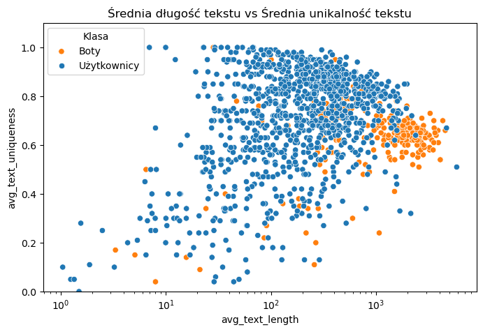

```python
figure, ax = plt.subplots(figsize=(8, 5))
sns.scatterplot(data = df, x = "avg_text_length", y = "avg_text_uniqueness", hue = "target")
plt.xscale("log")
ax.set_title("Średnia długość tekstu vs Średnia unikalność tekstu")
ax.legend(title='Klasa', labels=['Boty', 'Użytkownicy'])
ax.set_ylim(0,1.1)
```

```
(0.0, 10.0)
```

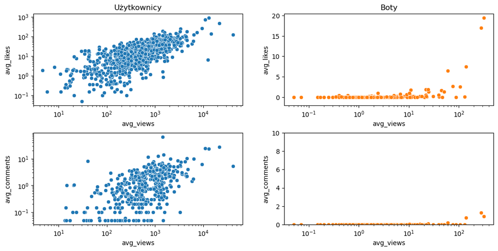

```python
figure, ax = plt.subplots(2,2, figsize=(13, 6))
plt.subplots_adjust(hspace=0.3)\

ax.flatten()
for tclass in df["target"].unique():
    subset = df[df["target"] == tclass]
    sns.scatterplot(data=subset, x="avg_views", y="avg_likes",ax=ax[0,tclass], c = 'tab:blue' if tclass==0 else 'tab:orange')


ax[0,0].set_title("Użytkownicy")
ax[0,0].set_xscale("log")
ax[0,0].set_yscale("log")

ax[0,1].set_title("Boty")
ax[0,1].set_xscale("log")


for tclass in df["target"].unique():
    subset = df[df["target"] == tclass]
    sns.scatterplot(data=subset, x="avg_views", y="avg_comments",ax=ax[1,tclass], c = 'tab:blue' if tclass==0 else 'tab:orange')

ax[1,0].set_xscale("log")
ax[1,0].set_yscale("log")
ax[1,1].set_xscale("log")
ax[1,1].set_ylim(0, 10)
```

W przypadku użytkowników wraz z większą ilością wyświetleń można spodziewać się większej liczby polubień i komentarzy, natomiast nie ma to zastosowania w przypadku botów.

### Podsumowanie:

Profile botów i prawdziwych użytkowników znacząco różnią się pod względem kompletności profilu, aktywności oraz charakteru publikowanych treści. Jedną z najbardziej widocznych cech botów jest wysoki udział wartości „Nieznane” w wielu zmiennych, oraz brak lub bardzo wybiórcze uzupełnianie informacji profilowych. Boty często nie posiadają podstawowych danych, takich jak zdjęcie, numer telefonu, status czy możliwość dodania do znajomych.

Z kolei profile prawdziwych użytkowników cechują się znacznie większą aktywnością społecznościową. Użytkownicy częściej uzupełniają swoje profile, publikują treści oraz korzystają z funkcji platformy społecznościowej. Charakteryzują się również większą liczbą wyświetleń, polubień i komentarzy, przy czym wraz ze wzrostem liczby wyświetleń rośnie także zaangażowanie w postaci reakcji. Taka zależność nie występuje w przypadku botów, których aktywność jest niska lub praktycznie nieobecna.

Dodatkowo zauważalne są różnice w cechach językowych publikowanych treści. Boty tworzą dłuższe teksty, zawierające więcej słów kluczowych. Teksty użytkowników są bardziej unikatowe i zróżnicowane pod względem treści.

Podsumowując, boty można scharakteryzować jako profile o niskiej kompletności, małej aktywności i schematycznych treściach, natomiast prawdziwi użytkownicy wykazują większe zaangażowanie, personalizację profilu oraz naturalne wzorce interakcji w social mediach.

## 4. Przetwarzanie danych

### Podział danych na zbiór treningowy i testowy

Nasz zbiór danych podzielimy w następujący sposób:

```python
from sklearn.model_selection import train_test_split

X = df.drop(columns=["target"])
y = df["target"]

# 70% danych jako zbiór treningowy, 30% zbiór testowy
X_train, X_test, y_train, y_test = train_test_split(
    X, y, test_size=0.3, random_state=420
)
```

### Pozbycie się zmiennych wysokoskorelowanych

##### Badanie zależności dla danych numerycznych

Do zbadania korelacji między zmiennymi numerycznymi użyjemy standardowej korelacji Pearsona.

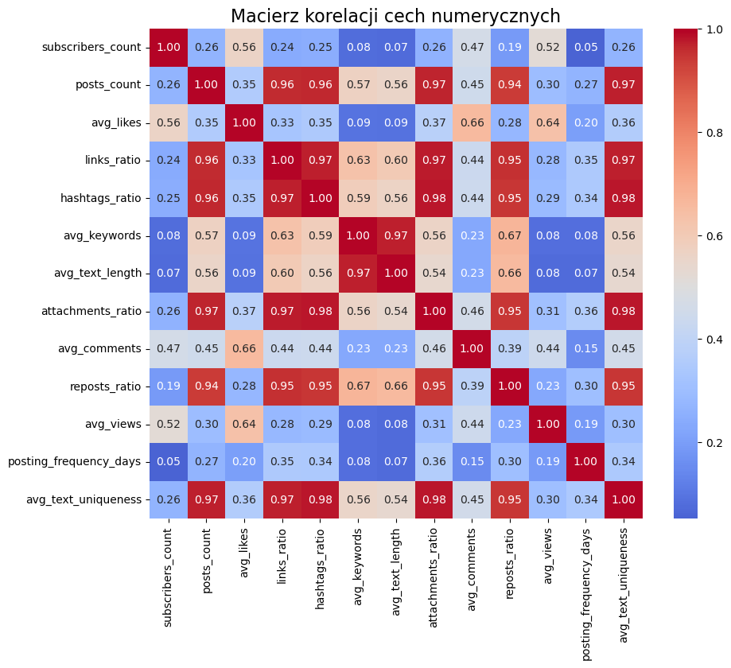

```python
corr_num = X_train[bins["num"]].corr(method="pearson")
plt.figure(figsize=(10, 8))
sns.heatmap(corr_num, annot=True, fmt=".2f", cmap="coolwarm", center=0.5)
plt.title("Macierz korelacji cech numerycznych", fontsize=16)
```

```python
from feature_engine.selection import SmartCorrelatedSelection

X_num =  X_train[bins["num"]]

scs = SmartCorrelatedSelection(
    variables=None,
    method='pearson',
    threshold=0.8  # Próg korelacji ustawiamy na 0.80
)

# Dopasowanie do danych
scs.fit(X_num)

# Cechy do usunięcia
num_to_drop = scs.features_to_drop_
num_left = [col for col in X_num.columns if col not in num_to_drop]

print(f"Cechy numeryczne do usunięcia: {len(num_to_drop)}")
for feature in num_to_drop:
    print(f"  - {feature}")

# Usunięcie cech z oryginalnego DataFrame
X_train = X_train.drop(columns=num_to_drop)
X_test = X_test.drop(columns=num_to_drop)

# Transformacja danych
X_uncorr = scs.transform(X_num)
print(f"\nIlość cech przed usunięciem: {X_num.shape[1]}")
print(f"Ilość cech po usunięciu: {X_uncorr.shape[1]}")
```

```
Cechy numeryczne do usunięcia: 6
  - links_ratio
  - hashtags_ratio
  - attachments_ratio
  - reposts_ratio
  - avg_text_uniqueness
  - avg_text_length

Ilość cech przed usunięciem: 13
Ilość cech po usunięciu: 7
```

##### Badanie zależności dla danych kategorycznych

Do zbadania korelacji między zmiennymi kategorycznymi wykorzystamy wpółczynnik Craméra (Cramér’s V).

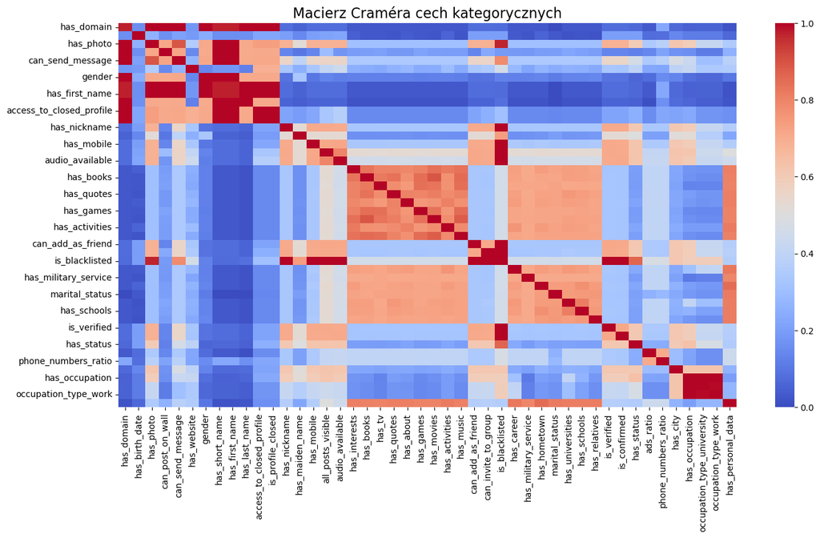

```python
# Zdefinowanie funkcji pomocniczej do obliczania współczynnika Craméra
def cramers_v(x, y):
    confusion = pd.crosstab(x, y)
    chi2 = ss.chi2_contingency(confusion)[0]
    n = confusion.sum().sum()
    phi2 = chi2 / n
    r, k = confusion.shape
    phi2corr = max(0, phi2 - ((k-1)*(r-1))/(n-1))
    rcorr = r - ((r-1)**2)/(n-1)
    kcorr = k - ((k-1)**2)/(n-1)
    return np.sqrt(phi2corr / min((kcorr-1), (rcorr-1)))

#Stworzenie macierzy Craméra
cramers_matrix = pd.DataFrame(
    index=bins["cat"],
    columns= bins["cat"],
    dtype=float
)

#Wypełnienie macierzy Craméra
for col1 in bins["cat"]:
    for col2 in bins["cat"]:
        cramers_matrix.loc[col1, col2] = cramers_v(X_train[col1], X_train[col2])

plt.figure(figsize=(16, 8))
sns.heatmap(cramers_matrix.astype(float), cmap="coolwarm", center=0.5)
plt.title("Macierz Craméra cech kategorycznych", fontsize=16)
plt.show()
plt.tight_layout()
```

```python
threshold = 0.85

upper = cramers_matrix.where(
    np.triu(np.ones(cramers_matrix.shape), k=1).astype(bool)
)

cat_to_drop = [
    col for col in upper.columns
    if any(upper[col] > threshold)
]

X_train = X_train.drop(columns=cat_to_drop)
X_test = X_test.drop(columns=cat_to_drop)

print(f"Cechy binarne/kategoryczne do usunięcia: {len(cat_to_drop)}")
for col in cat_to_drop:
    print(f"  - {col}")

print(f"Ilość cech binarnych/kategorycznych przed usunięciem: {len(bins['cat'])}")
print(f"Ilość cech po usunięciu: {len(bins['cat'])-len(cat_to_drop)}")
```

```
Cechy binarne/kategoryczne do usunięcia: 18
  - has_photo
  - can_post_on_wall
  - can_send_message
  - gender
  - has_short_name
  - has_first_name
  - has_last_name
  - access_to_closed_profile
  - is_profile_closed
  - has_movies
  - has_music
  - is_blacklisted
  - is_verified
  - is_confirmed
  - has_status
  - occupation_type_university
  - occupation_type_work
  - has_personal_data
Ilość cech binarnych/kategorycznych przed usunięciem: 46
Ilość cech po usunięciu: 28
```

### Skalowanie danych

W przypadku naszych danych numerycznych zastosujemy dwa rodzaje skalowania:

- Transformacja logarytmiczna - polega na zastosowaniu funkcji logarytmu do wartości, głównie w celu zmniejszenia skośności rozkładu danych oraz kompresji zakresu, w którycm się te dane znajdują.
- Standaryzacja - to proces przekształcania cech (kolumn) w danych tak, aby miały one średnią równą 0 i odchylenie standardowe równe 1. Jest to jedna z najpopularniejszych technik przygotowania danych w uczeniu maszynowym.

```python
from sklearn.pipeline import Pipeline
from sklearn.preprocessing import StandardScaler
from sklearn.compose import ColumnTransformer

# Transformacja logarytmiczna z obsługą wartości -1
def log_transform(X, cols):
    X = X.copy()
    for col in cols:
        if col not in X.columns:
            continue
        X[col] = X[col].replace(-1, np.nan)
        X[col] = np.log1p(X[col])
        X[col] = X[col].replace(np.nan, -1)
    return X

# Kolumny do transformacji logarytmicznej
cols_to_log = [
    "subscribers_count",
    "avg_likes",
    "avg_views",
    "avg_keywords",
    "posting_frequency_days"
]

# Transformer do standaryzacji
standard_scaler = ColumnTransformer(
    transformers=[
        ("scale", StandardScaler(), num_left)
    ],
    remainder="passthrough"
)

pipeline_v3 = Pipeline([
    ("cleaning", cleaning_pipeline),
    ("transform_city", FunctionTransformer(transform_city_column, validate=False)),
    ("log_preprocess", FunctionTransformer(log_transform, kw_args={"cols": cols_to_log}, validate=False)),
    ("standard_scaling", standard_scaler)
])
pipeline_v3.set_output(transform="pandas")

#X_transformed = pipeline_v3.fit_transform(df)
#X = pd.DataFrame(X_transformed, columns=df.columns).drop("target", axis=1)
```

```
Pipeline(steps=[('cleaning',
                 Pipeline(steps=[('drop_all_nan_cols',
                                  FunctionTransformer(func=<function drop_all_nan_columns at 0x0000018C01754160>)),
                                 ('replace_unknown_nan',
                                  FunctionTransformer(func=<function replace_unknown_and_nan at 0x0000018C704C3C70>))])),
                ('transform_city',
                 FunctionTransformer(func=<function transform_city_column at 0x0000018C6899DF30>)),
                ('l...
                 FunctionTransformer(func=<function log_transform at 0x0000018C016E0AF0>,
                                     kw_args={'cols': ['subscribers_count',
                                                       'avg_likes', 'avg_views',
                                                       'avg_keywords',
                                                       'posting_frequency_days']})),
                ('standard_scaling',
                 ColumnTransformer(remainder='passthrough',
                                   transformers=[('scale', StandardScaler(),
                                                  ['subscribers_count',
                                                   'posts_count', 'avg_likes',
                                                   'avg_keywords',
                                                   'avg_comments', 'avg_views',
                                                   'posting_frequency_days'])]))])
```

### Wybranie najlepszych cech do naszego modelu

W zbiorze danych znajduje się 60 kolumn, jednocześnie duża część z nich to dane kategoryczne. Żeby zmniejszyć czas nauki modelu klasyfikacji i być może zwiększyć zdolność modelu do uogólniania, wydobędziemy tylko te kolumny które mają największy wpływ na zmienną target. Spośród wybranych dotąd kolumn, do modelu wybierzemy tylko te ,które mają największą wartość informacji wzajemnej z targetem.

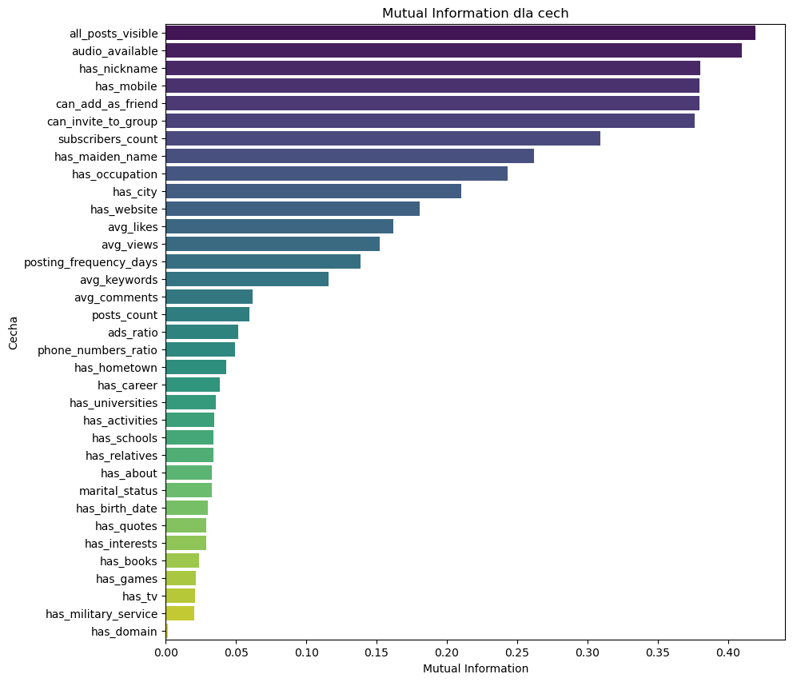

```python
from sklearn.feature_selection import SelectKBest, mutual_info_classif

discrete_mask = [
    True
    if (col not in num_left)
    else False
    for col in X_train.columns
]

mi = mutual_info_classif(X_train, y_train, discrete_features=discrete_mask)
mi_series = pd.Series(mi, index=X_train.columns)
mi_sorted = mi_series.sort_values(ascending=False)

plt.figure(figsize=(10, 10))
sns.barplot(
    x=mi_sorted.values,
    y=mi_sorted.index,
    orient="h",
    hue=mi_sorted.index,
    palette="viridis",
)
plt.title("Mutual Information dla cech")
plt.xlabel("Mutual Information")
plt.ylabel("Cecha")
plt.show()
```

```python
pipeline_v4 = Pipeline([
    ("feature_preprocessing", pipeline_v3),
    ("feature_selection", SelectKBest(score_func=mutual_info_classif, k=15)),
])
pipeline_v4.set_output(transform="pandas")

X_train = pipeline_v4.fit_transform(X_train, y_train)
X_train.columns = [col.replace("scale__", "")
                        .replace("remainder__", "") for col in X_train.columns]

X_test  = pipeline_v4.transform(X_test)
X_test.columns = [col.replace("scale__", "")
                        .replace("remainder__", "") for col in X_test.columns]

selector = pipeline_v4.named_steps["feature_selection"]
selected_columns = X_train.columns


print("Wybrane kolumny:")
for col in selected_columns:
    print(f"- {col}")
```

```
Wybrane kolumny:
- subscribers_count
- avg_likes
- avg_keywords
- avg_views
- posting_frequency_days
- has_website
- has_nickname
- has_maiden_name
- has_mobile
- all_posts_visible
- audio_available
- can_add_as_friend
- can_invite_to_group
- has_city
- has_occupation
```

## 5. Stworzenie modeli

##### Regresja Logistyczna

- **Opis działania:** Regresja logistyczna to model liniowy używany do zadań klasyfikacyjnych. Mimo swojej nazwy, nie służy do regresji, lecz do przewidywania prawdopodobieństwa przynależności obserwacji do określonej klasy. Model ten oblicza ważoną sumę zmiennych wejściowych (podobnie jak w regresji liniowej), a następnie przepuszcza wynik przez funkcję logistyczną (sigmoidalną), która "spłaszcza" wartości do przedziału od 0 do 1. Wynik ten jest interpretowany jako prawdopodobieństwo. Decyzja o przypisaniu do klasy podejmowana jest na podstawie progu (zazwyczaj 0.5) – jeśli prawdopodobieństwo jest wyższe od progu, obserwacja zostaje przypisana do klasy pozytywnej.

Using Machine Learning Techniques to Identify Bot Accounts on a Social Network

https://ieeexplore.ieee.org/document/9470605

##### Las Losowy (Random Forest)

- **Opis działania:** Las losowy jest metodą zespołową (ensemble), która tworzy wiele pojedynczych drzew decyzyjnych w procesie treningowym, a następnie agreguje ich wyniki. Każde drzewo w lesie jest budowane na losowej próbce danych treningowych (bootstrap) oraz przy użyciu losowego podzbioru cech do podziału w każdym węźle. Taka podwójna losowość redukuje wariancję modelu i minimalizuje ryzyko przeuczenia (overfitting), które jest częstym problemem dla pojedynczych drzew decyzyjnych. Ostateczna decyzja klasyfikacyjna jest podejmowana poprzez głosowanie większościowe – klasa, którą wskazała większość drzew, staje się wynikiem predykcji całego lasu.

Optimized Random Forest Model for Botnet Detection Based on DNS Queries

https://ieeexplore.ieee.org/document/9331819

##### Wzmacnianie Gradientowe (Gradient Boosting)

- **Opis działania:** Wzmacnianie gradientowe to kolejna zaawansowana technika zespołowa, która buduje modele w sposób sekwencyjny. W przeciwieństwie do lasów losowych, gdzie drzewa powstają niezależnie, tutaj każde nowe drzewo jest tworzone w celu korekty błędów popełnionych przez poprzednie. Proces rozpoczyna się od prostego modelu, a następnie iteracyjnie dodawane są kolejne, które uczą się na resztach (residual errors) z poprzedniego kroku. Algorytm wykorzystuje metodę optymalizacji opartą na gradiencie funkcji straty, aby zminimalizować błąd całego zespołu. Dzięki temu podejściu modele oparte na wzmacnianiu gradientowym często osiągają najwyższą skuteczność predykcyjną.

Incremental Learning of Gradient Boosting Decision Trees to Detect Botnets in Internet of Things

https://www.mdpi.com/1424-8220/24/7/2083

```python
from sklearn.ensemble import RandomForestClassifier, GradientBoostingClassifier
from sklearn.linear_model import LogisticRegression
from sklearn.metrics import accuracy_score

rf_model = RandomForestClassifier(max_depth=5, min_samples_leaf=50, random_state=420)
gb_model = GradientBoostingClassifier(
    max_depth=5, min_samples_leaf=50, random_state=420
)
lr_model = LogisticRegression(random_state=420)

rf_model.fit(X_train, y_train)
gb_model.fit(X_train, y_train)
lr_model.fit(X_train, y_train)
```

```
LogisticRegression(random_state=420)
```

#### Mierzenie skuteczności modeli

Do oceny i porównania skuteczności zaimplementowanych modeli wykorzystano cztery kluczowe mierniki:

1. **Accuracy (Dokładność):** Procent poprawnie sklasyfikowanych obserwacji w całym zbiorze testowym.
2. **Precision (Precyzja):** To prawdopodobieństwo uzyskania dodatniego wyniku testu, pod warunkiem, że dany obiekt rzeczywiście uzyska wynik dodatni.
3. **Recall (Czułość):** Czułość mówi nam o tym, jaki jest udział prawidłowo zaprognozowanych przypadków pozytywnych (TP) wśród wszystkich przypadków pozytywnych.
4. **AUC (Area Under the ROC Curve):** Pole pod krzywą ROC. Miernik ten ocenia zdolność modelu do rozróżniania między klasami. Wartość bliska 1.0 oznacza model o doskonałej mocy separacji, podczas gdy wartość 0.5 odpowiada modelowi losowemu.

```python
models = {
    "Las Losowy": rf_model.predict(X_test),
    "Gradient Boosting": gb_model.predict(X_test),
    "Regresja Logistyczna": lr_model.predict(X_test)
}
```

#### Macierz pomyłek dla wybranych modeli

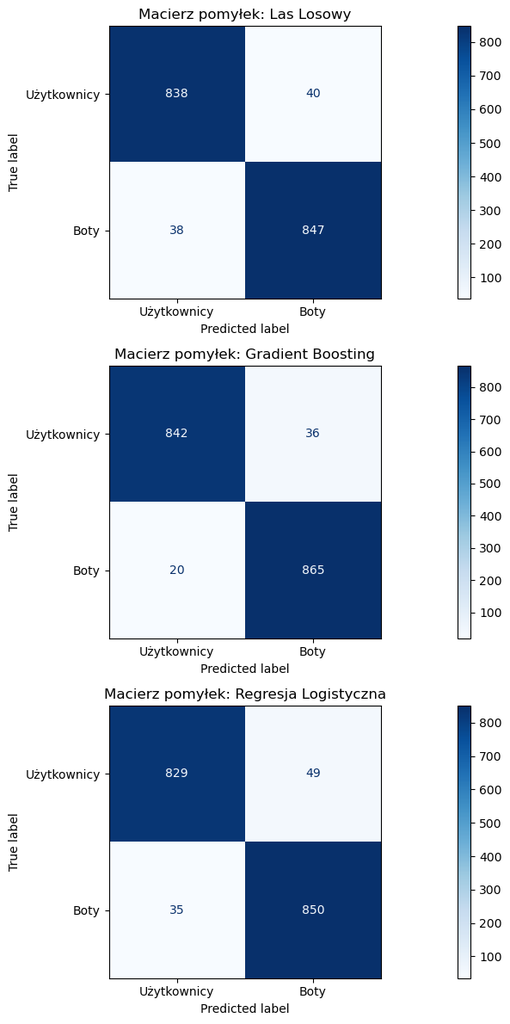

```python
from sklearn.metrics import ConfusionMatrixDisplay, confusion_matrix, precision_score, recall_score, roc_auc_score

rf_cm = confusion_matrix(y_test, models["Las Losowy"])
disp = ConfusionMatrixDisplay(confusion_matrix=rf_cm, display_labels=["Użytkownicy", "Boty"])

gb_cm = confusion_matrix(y_test, models["Gradient Boosting"])
disp = ConfusionMatrixDisplay(confusion_matrix=gb_cm, display_labels=["Użytkownicy", "Boty"])

lr_cm = confusion_matrix(y_test, models["Regresja Logistyczna"])
disp = ConfusionMatrixDisplay(confusion_matrix=lr_cm, display_labels=["Użytkownicy", "Boty"])

fig, axes = plt.subplots(3, 1, figsize=(18, 12))
axes = axes.flatten()
for idx, (model_name, y_pred) in enumerate(models.items()):
    cm = confusion_matrix(y_test, y_pred)
    disp = ConfusionMatrixDisplay(confusion_matrix=cm, display_labels=["Użytkownicy", "Boty"])
    disp.plot(ax=axes[idx], cmap="Blues", colorbar=True)
    axes[idx].set_title(f"Macierz pomyłek: {model_name}")

plt.tight_layout()
plt.show()
```

```
                      accuracy  precision    recall   roc_auc
Las Losowy            0.955757   0.954904  0.957062  0.955752
Gradient Boosting     0.968236   0.960044  0.977401  0.968199
Regresja Logistyczna  0.952354   0.945495  0.960452  0.952322
```

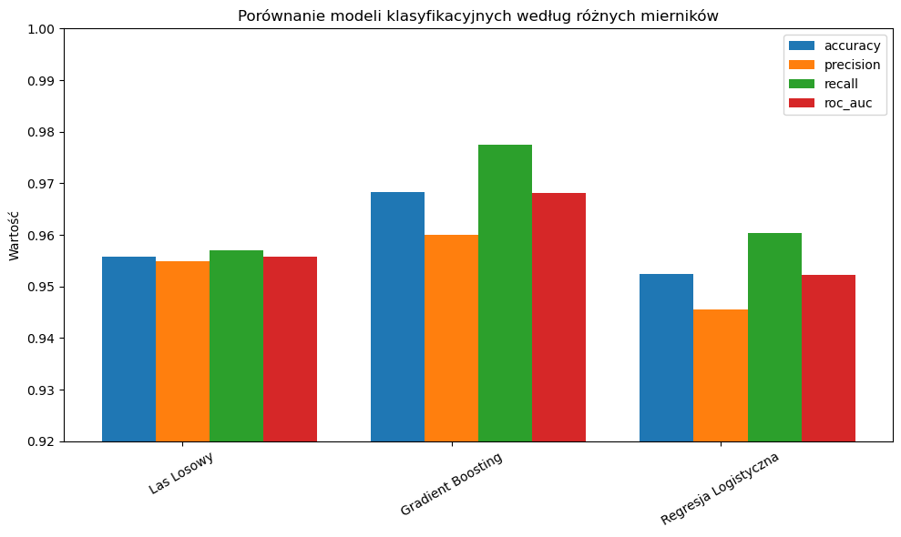

```python
mierniki = {}
for name in models.keys():
    mierniki[name] = {"accuracy": 0, "precision": 0, "recall": 0, "roc_auc": 0}

    mierniki[name]["accuracy"] = accuracy_score(y_test, models[name])
    mierniki[name]["precision"] = precision_score(y_test, models[name])
    mierniki[name]["recall"] = recall_score(y_test, models[name])
    mierniki[name]["roc_auc"] = roc_auc_score(y_test, models[name])

scores_df = pd.DataFrame(mierniki).T
print(scores_df)

width = 0.2
x = np.arange(len(scores_df.index))
plt.figure(figsize=(10, 6))

for i, metric in enumerate(scores_df.columns):
    plt.bar(x + i * width, scores_df[metric], width, label=metric)

plt.xticks(x + width, models, rotation=30)
plt.ylabel("Wartość")
plt.title("Porównanie modeli klasyfikacyjnych według różnych mierników")
plt.ylim(0.92, 1.0)
plt.legend()
plt.tight_layout()
plt.show()
```

#### Walidacja krzyżowa (bazowych modeli)

```python
from sklearn.model_selection import cross_val_score, KFold

cv = KFold(n_splits=5, shuffle=True, random_state=420)
cv_scores = {}

for name, model in {
    "Las Losowy": rf_model,
    "Gradient Boosting": gb_model,
    "Regresja Logistyczna": lr_model
}.items():
    scores = cross_val_score(model, X_train, y_train, cv=cv, scoring="accuracy")
    cv_scores[name] = scores
    print(f"\n{name} - Walidacja krzyżowa:")
    print(f"Średnia dokładność: {scores.mean():.4f} (+/- {scores.std() * 2:.4f})")
    print(f"Wyniki poszczególnych foldów: {scores}")
```

```
Las Losowy - Walidacja krzyżowa:
Średnia dokładność: 0.9528 (+/- 0.0218)
Wyniki poszczególnych foldów: [0.94775213 0.95742092 0.93430657 0.95863747 0.96593674]

Gradient Boosting - Walidacja krzyżowa:
Średnia dokładność: 0.9684 (+/- 0.0139)
Wyniki poszczególnych foldów: [0.96840826 0.9622871  0.95985401 0.97201946 0.97931873]

Regresja Logistyczna - Walidacja krzyżowa:
Średnia dokładność: 0.9465 (+/- 0.0173)
Wyniki poszczególnych foldów: [0.94532199 0.94890511 0.93065693 0.9513382  0.95620438]
```

#### Wizualizacja wyników walidacji krzyżowej

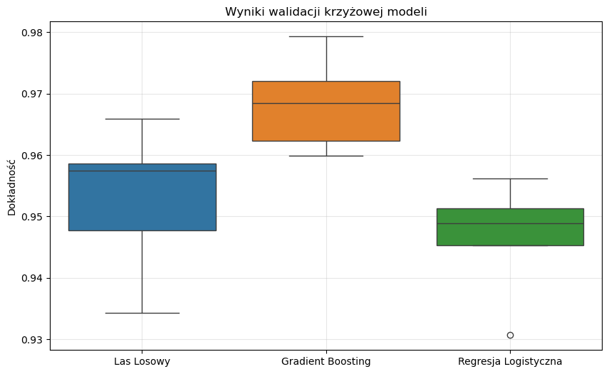

```python
cv_results = pd.DataFrame(cv_scores)
plt.figure(figsize=(10, 6))
sns.boxplot(data=cv_results)
plt.title("Wyniki walidacji krzyżowej modeli")
plt.ylabel("Dokładność")
plt.grid(True, alpha=0.3)
plt.show()
```

#### Optymalizacja hiperparametrów dla każdego z modeli

```python
from sklearn.model_selection import GridSearchCV

rf_param_grid = {"n_estimators":[10, 30, 50, 80], "max_depth": [3, 5, 7], "min_samples_leaf": [45, 60, 80]}
gb_param_grid = {"learning_rate":[0.1, 0.3, 0.5], "n_estimators": [10, 30, 50, 80], "max_depth": [3, 5, 7], "min_samples_leaf":[30, 50, 80]}
lr_param_grid = {"C":[0.01, 0.1, 1, 10], "solver":["lbfgs", "liblinear"], "max_iter":[50, 100, 200]}

rf_grid_search = GridSearchCV(RandomForestClassifier(random_state=420), rf_param_grid, cv=cv, scoring="accuracy", n_jobs=-1)
gb_grid_search = GridSearchCV(GradientBoostingClassifier(random_state=420), gb_param_grid, cv=cv, scoring="accuracy", n_jobs=-1)
lr_grid_search = GridSearchCV(LogisticRegression(random_state=420), lr_param_grid, cv=cv, scoring="accuracy", n_jobs=-1)

rf_grid_search.fit(X_train, y_train)
gb_grid_search.fit(X_train, y_train)
lr_grid_search.fit(X_train, y_train)
```

```
GridSearchCV(cv=KFold(n_splits=5, random_state=420, shuffle=True),
             estimator=LogisticRegression(random_state=420), n_jobs=-1,
             param_grid={'C': [0.01, 0.1, 1, 10], 'max_iter': [50, 100, 200],
                         'solver': ['lbfgs', 'liblinear']},
             scoring='accuracy')
```

```python
optimized_models = {
    "Las Losowy": rf_grid_search.best_estimator_,
    "Gradient Boosting": gb_grid_search.best_estimator_,
    "Regresja Logistyczna": lr_grid_search.best_estimator_
}
optimized_models_pred = {}

for model_name, model in optimized_models.items():
    optimized_models_pred[model_name] = model.predict(X_test)
```

#### Wyniki modeli po zastosowaniu optymalizacji parametrów

```
                      accuracy  precision    recall   roc_auc
Las Losowy            0.956324   0.952915  0.960452  0.956308
Gradient Boosting     0.966534   0.956858  0.977401  0.966491
Regresja Logistyczna  0.955190   0.949777  0.961582  0.955165
```

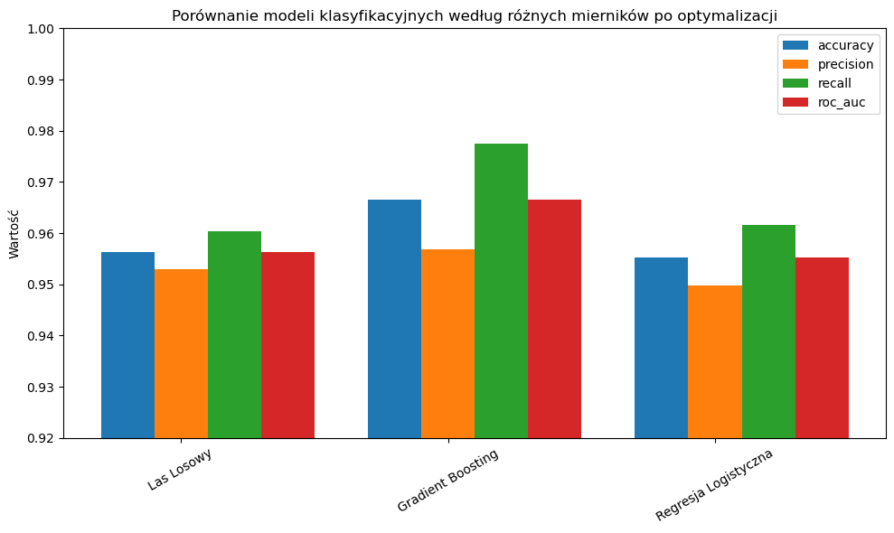

```python
mierniki_opt = {}
for name in optimized_models.keys():
    mierniki_opt[name] = {"accuracy": 0, "precision": 0, "recall": 0, "roc_auc": 0}

    mierniki_opt[name]["accuracy"] = accuracy_score(y_test, optimized_models_pred[name])
    mierniki_opt[name]["precision"] = precision_score(y_test, optimized_models_pred[name])
    mierniki_opt[name]["recall"] = recall_score(y_test, optimized_models_pred[name])
    mierniki_opt[name]["roc_auc"] = roc_auc_score(y_test, optimized_models_pred[name])

opt_scores_df = pd.DataFrame(mierniki_opt).T
print(opt_scores_df)

width = 0.2
x = np.arange(len(opt_scores_df.index))
plt.figure(figsize=(10, 6))

for i, metric in enumerate(opt_scores_df.columns):
    plt.bar(x + i * width, opt_scores_df[metric], width, label=metric)

plt.xticks(x + width, optimized_models, rotation=30)
plt.ylabel("Wartość")
plt.title("Porównanie modeli klasyfikacyjnych według różnych mierników po optymalizacji")
plt.ylim(0.92, 1.0)
plt.legend()
plt.tight_layout()
plt.show()
```

### Ocena jakości modeli

##### Ważność cech dla każdego z modeli

```python
f_names = selected_columns

f_importances = {
    "Las Losowy": optimized_models["Las Losowy"].feature_importances_,
    "Gradient Boosting": optimized_models["Gradient Boosting"].feature_importances_,
    "Regresja Logistyczna": np.abs(optimized_models["Regresja Logistyczna"].coef_[0])
}
```

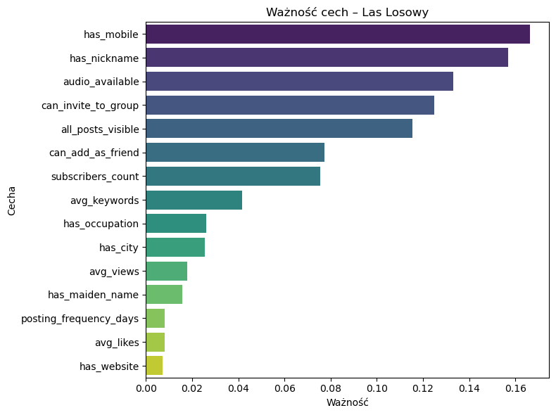

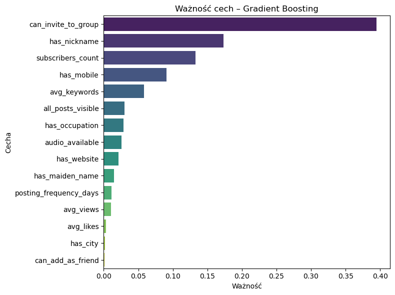

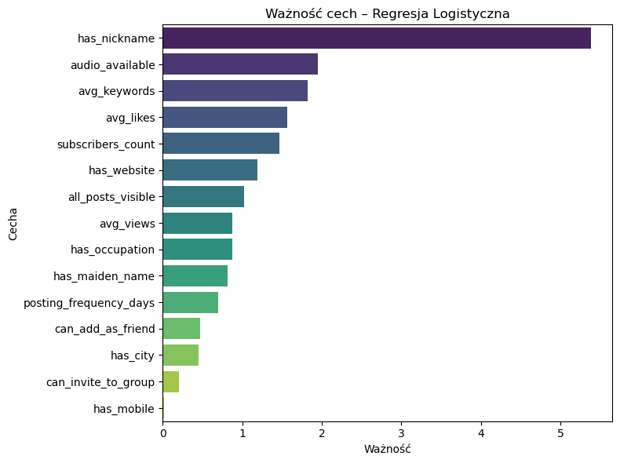

```python
for model_name, importances in f_importances.items():
    importance_df = pd.DataFrame(
        {"feature": f_names, "importance": importances}
    ).sort_values(by="importance", ascending=False)

    plt.figure(figsize=(8, 6))
    sns.barplot(
        data=importance_df,
        x="importance",
        y="feature",
        palette="viridis",
        hue="feature",
        legend=False,
    )
    plt.title(f"Ważność cech – {model_name}")
    plt.xlabel("Ważność")
    plt.ylabel("Cecha")
    plt.tight_layout()
    plt.show()
```

### Sposób oceny ważności cech dla każdego z użytych modeli

#### Las losowy

Ważność cech w lesie losowym została obliczona na podstawie współczynnika Giniego (impurity-based feature importance). Metoda ta mierzy średnią redukcję nieczystości węzłów spowodowaną przez każdą cechę podczas konstruowania drzew w lesie.

#### GradientBoosting

W modelu GradientBoosting ważność cech została również oceniona na podstawie redukcji nieczystości. Model wykorzystywał domyślną funkcję kryterium 'friedman_mse' do oceny jakości podziałów oraz funkcję straty odpowiednią dla problemu klasyfikacji binarnej.

#### Regresja logistyczna

Ważność cech w regresji logistycznej została określona na podstawie wartości bezwzględnych współczynników regresji. Model wykorzystywał domyślną regularyzację L2 (C=1.0).

## 6. Podsumowanie wyników i wnioski

Przeprowadzone badanie miało na celu klasyfikację kont użytkowników platformy vk.com na konta autentyczne oraz boty. Już na etapie eksploracji danych zauważono istotne różnice pomiędzy kontami botów i prawdziwych użytkowników. Boty charakteryzowały się:

- niską kompletnością profilu i dużym udziałem wartości „Nieznane”,
- minimalną lub zerową aktywnością (brak postów, polubień, komentarzy),
- treściami o wysokim nasyceniu słowami kluczowymi,
- brakiem naturalnych zależności pomiędzy wyświetleniami a zaangażowaniem.

Z kolei prawdziwi użytkownicy wykazywali większe zaangażowanie społeczne, częściej uzupełniali dane profilowe, publikowali treści i generowali naturalne interakcje (polubienia, komentarze, reposty). Widoczne były także typowe dla ludzi zależności pomiędzy popularnością treści a poziomem reakcji.

Do klasyfikacji zastosowaliśmy trzy modele: Las Losowy, Gradient Boosting oraz Regresję Logistyczną. Już modele bazowe osiągały bardzo wysoką skuteczność – szczególnie algorytmy drzewiaste, z dokładnością sięgającą około 97%. Najlepsze wyniki pod względem czułości (recall) uzyskał Gradient Boosting, co jest kluczowe w kontekście wykrywania botów.

Analiza istotności cech pozwoliła zidentyfikować zmienne, które w największym stopniu wpływały na decyzje klasyfikacyjne poszczególnych modeli.

- W przypadku lasu losowego najwyższą istotność uzyskały cechy związane z kompletnością profilu oraz możliwością interakcji z innymi użytkownikami. Do najważniejszych zmiennych należały: obecność numeru telefonu w profilu, posiadanie pseudonimu (nickname), dostępność plików audio, widoczność wszystkich postów, możliwość dodania użytkownika do grona znajomych lub zaproszenia do grupy, a także liczba subskrybentów.
- W modelu Gradient Boosting zdecydowanie najbardziej istotną cechą okazała się możliwość zaproszenia użytkownika do grupy (can_invite_to_group), która dominowała nad pozostałymi zmiennymi. Kolejne cechy miały już mniejsze znaczenie i obejmowały: posiadanie pseudonimu, liczbę subskrybentów, obecność numeru telefonu w profilu oraz średnią liczbę słów kluczowych w publikowanych postach.
- W przypadku regresji logistycznej największy wpływ na klasyfikację miała cecha informująca o posiadaniu pseudonimu. Pozostałe zmienne charakteryzowały się mniejszym znaczeniem i obejmowały: dostępność treści audio na profilu, średnią liczbę słów kluczowych w postach, liczbę polubień oraz liczbę subskrybentów. Rozkład istotności cech w tym modelu był bardziej wyrównany (nie licząc najbardziej istotnej cechy).

Podsumowując, badanie potwierdziło, że konta botów i prawdziwych użytkowników różnią się a odróżnianie tych kont sprowadza się do badania kompletności profilu, oraz interakcji z innymi użytkownikami. Najlepsze rezultaty osiągają modele drzewiaste, w szczególności Gradient Boosting, który okazał się najbardziej efektywny do wykrywania botów w mediach społecznościowych.